# Class 9 Lab - Modes of Inference

We are going to use the tadpole example to examine different approaches for analyzing data in R. Our goal is to estimate the probability of detection (theta) of tadpoles. We release n=50 tadpole in a pond. Later we go out to sample and resight y=20 individuals.

```r
r <- 20
N <- 50
```

First, let’s try a brute force approach where we plot the likelihood directly. Use the PMF of the binomial distribution.

Start by defining all possible values for theta:

```r
theta=seq(0,1, by = 0.01)
x=rep(0,length(theta))
```

Examine the probability of each theta given the data

```r
for (i in 1:length(theta)){
  x[i] <- (factorial(N) / (factorial(N) * factorial(N-r))) * theta[i]^r * (1-theta[i])^(N-r)
}
```

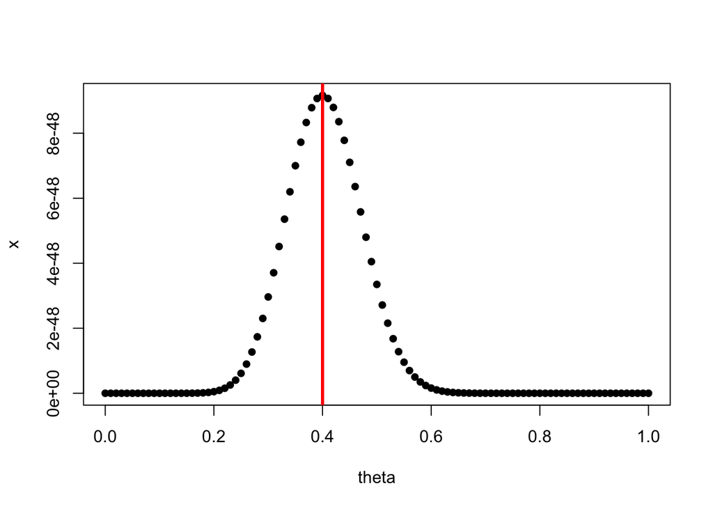

Now we can see that the likelihood is maximized when theta = 0.4. __________________________________________________________________________

First define negative log-likelihood function:

```r
nll <- function(p) {
  -dbinom(r, size = N, prob = p, log = TRUE)
}
```

Why do we use the negative log-likelihood? What would happen if we used just the negative likelihood? What about just the likelihood? *You might want to ?dbinom if you are unfamility with this function

Next minimize the function for observed data and return MLE. We use the quasi-Newton method (BFGS) for optimization.

```r
fit <- optim(par = 0.5, fn = nll, method = "BFGS")
```

Examine the value for which the parameter is maximized.

```
## [1] 0.4
```

Note we can use the GLM function for the same thing. Note this estimates the coefficient on the logit scale. What is the standard error of the coefficient? Is it large? Why might that be?

```r
fm <- glm(cbind(20,30) ~ 1, family = binomial)
summary(fm)
```

```
##
## Call:
## glm(formula = cbind(20, 30) ~ 1, family = binomial)
##
## Deviance Residuals:
## [1]  0
##
## Coefficients:
##             Estimate Std. Error z value Pr(>|z|)
## (Intercept)  -0.4055     0.2887  -1.405     0.16
##
## (Dispersion parameter for binomial family taken to be 1)
##
##     Null deviance:  0.0000e+00  on 0  degrees of freedom
## Residual deviance: -4.4409e-15  on 0  degrees of freedom
## AIC: 6.3333
##
## Number of Fisher Scoring iterations: 2
```

```r
plogis(fm$coefficients)
```

```
## (Intercept)
##         0.4
```

Now is a good time to start familiarizing yourself with the `glm` and `lm` functions.

We are not going to do a Bayesian analysis of these data but we will do one when we return to the topic in a later class.